# Do balanced designs have greater power?

Michael Hunt

26/11/2024

A script to test how the power of a study to distinguish two populations that really do differ in some respect is impacted by the relative sizes of the samples, given a fixed total numer of replicates.

We take the case where the total replicate number is 40, and we split it between two samples of sizes (2,38), (3,37),….(20,20),….(37,3), (38,2).

Suppose we had a population with a mean mass of 100 kg and another with a mean mass of 110 kg, each with standard deviation of 10 kg, and time to take 40 replicates. We could take a proportion p from one population, making that sample be of size 40p, and a proportion 1-p from the other population, so that sample would be of size 40(1-p).

If p = 0.5 then each sample is of size 20 and we have a balanced design.

Draw samples n1 and n2 such that n1 + n2 = N from each population. Find power of a t-test by carrying one out 1000 times. Repat for another chocie of n1, n2.w

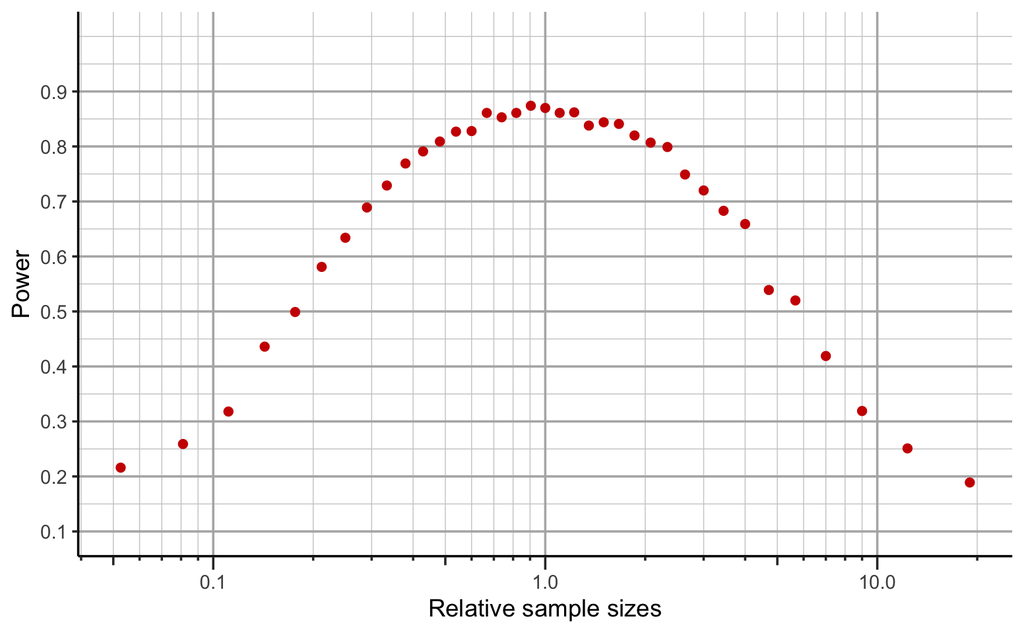

### Generalise - power as a function of balance and effect size